# EDA: Salaries of MLB Batters from 1985 to 2020

Yun Hwan Choi

### Table of Contents

#### Introduction/Data Processing

#### Setting up/Data Merging

#### Exploratory Data Analysis

##### I. Initial exploration

###### A. Batting Average distribution

###### B. Home Run distribution

###### C. Salary

##### II. Identifying Predictors for Postseason

###### A. Setting up

###### B. Total Batting Average

###### C. Runs

###### D. Home Runs

###### E. Strikeouts

###### F. GIDP

###### G. Salary/Payroll

##### III. Conclusion

# Introduction/Data Processing

The data from the Lahman open source originally contained three dataframes, Batting.csv, BattingPost.csv, and Salaries.csv. I attempted to merge and process these by taking the following steps.

- Cut out all data from before 1985 to make data easier to handle, and also to ensure that most data had salary information as salary information is only available from 1985.
- To distinguish stats from regular season and Postseason, added a binary indicator variable `postseason` saying whether the statistic was from a regular season or Postseason.
- Created a new identifier variable that identifies a statistic for a player in a specific year for a specific team, for all three tables
- Merged the three datasets into one
- Added new variables `BA` (Batting average) and `Kperc` (Strikeout percentage) which can be calculated from the given information.
- Added a new variable `postseason_app` (postseason appearance) indicating whether a team that the player played for that season ended up making it to the playoffs or not.

These steps are outlined in the next section.

In the initial exploration stage, I attempted to confirm patterns and trends based on knowledge I have about baseball statistics. Then, via EDA, I attempted to identify the greatest determinant of a team making it into the postseason. I hypothesized that the total cumulative runs of a team in a given season would be a good predictor of the team making it to the postseason.

# Setting up/Data Merging

Importing tidyverse package…

```r
library(tidyverse)
```

Loading data…

```r
# Loading Batting Data
batting = read_csv("data/Batting.csv")
batting_post = read_csv("data/BattingPost.csv")
salaries = read_csv("data/Salaries.csv")
```

Applying filters to select only batting data from 1985

```r
batting <- filter(batting, yearID >= 1985)
batting_post <- filter(batting_post, yearID >= 1985)
```

Final merged dataframe including information about each batter’s season and the salary earned

```r
# Creating new ID key for each player and the year/team they played in
merged_batting <- bind_rows(batting, batting_post) %>%
  unite('playerseasonID', c("yearID", "playerID", "teamID"), remove = FALSE) %>%
  mutate(
    postseason = if_else(is.na(round), 0, 1) #postseason indicator
  )

# Postseason appearance indicator
merged_batting_postseason_app <- merged_batting %>% group_by(playerseasonID) %>%
  summarise(postseason_app = max(postseason)) %>%
  inner_join(merged_batting, by = "playerseasonID") %>%
  mutate(postseason = if_else(postseason == 1, 'Y', 'N')) %>%
  mutate(postseason_app = if_else(postseason_app == 1, 'Y', 'N'))
# Merging with Salary Data and adding new metrics
df <- salaries %>%
  unite('playerseasonID', c("yearID", "playerID", "teamID"), remove = FALSE) %>%
  select('playerseasonID', 'salary') %>%
  right_join(merged_batting_postseason_app, by = "playerseasonID") %>%
  mutate(BA = H/AB) %>% # batting average
  mutate(Kperc = SO/AB) %>% # strikeout percentage
  # reordering columns
  relocate(salary, .after = last_col()) %>%
  relocate(c(playerseasonID, playerID, yearID, teamID, stint, lgID)) %>%
  relocate(c(postseason, postseason_app, round), .after = lgID) %>%
  relocate(c(BA, Kperc), .after = AB)

df
```

```
## # A tibble: 57,105 x 29
##    playerseasonID playerID yearID teamID stint lgID  postseason postseason_app
##    <chr>          <chr>     <dbl> <chr>  <dbl> <chr> <chr>      <chr>
##  1 1985_barkele0~ barkele~   1985 ATL        1 NL    N          N
##  2 1985_bedrost0~ bedrost~   1985 ATL        1 NL    N          N
##  3 1985_benedbr0~ benedbr~   1985 ATL        1 NL    N          N
##  4 1985_campri01~ campri01   1985 ATL        1 NL    N          N
##  5 1985_ceronri0~ ceronri~   1985 ATL        1 NL    N          N
##  6 1985_chambch0~ chambch~   1985 ATL        1 NL    N          N
##  7 1985_dedmoje0~ dedmoje~   1985 ATL        1 NL    N          N
##  8 1985_forstte0~ forstte~   1985 ATL        1 NL    N          N
##  9 1985_garbege0~ garbege~   1985 ATL        1 NL    N          N
## 10 1985_harpete0~ harpete~   1985 ATL        1 NL    N          N
## # ... with 57,095 more rows, and 21 more variables: round <chr>, G <dbl>,
## #   AB <dbl>, BA <dbl>, Kperc <dbl>, R <dbl>, H <dbl>, `2B` <dbl>, `3B` <dbl>,
## #   HR <dbl>, RBI <dbl>, SB <dbl>, CS <dbl>, BB <dbl>, SO <dbl>, IBB <dbl>,
## #   HBP <dbl>, SH <dbl>, SF <dbl>, GIDP <dbl>, salary <dbl>
```

# Exploratory Data Analysis

### I. Initial Exploration

Here I attempt to play around with the dataframe, and ensure whether the dataset reflects common sense knowledge about baseball.

#### A. Batting Average distribution

Batting average is the most widely used metric that evaluates the level of skill of a batter. It indicates the number of hits `H` a player had divided by the number of chances (“at bats”) `AB` a player was given. The higher the average, the better, meaning that the batter was able to convert a higher percentage of his opportunities to hit the ball into play. Around .240~.260 is considered average. Above .300 is considered elite. Below .200 is considered poor. On a distribution graph I expect to see a peak somewhere around .250.

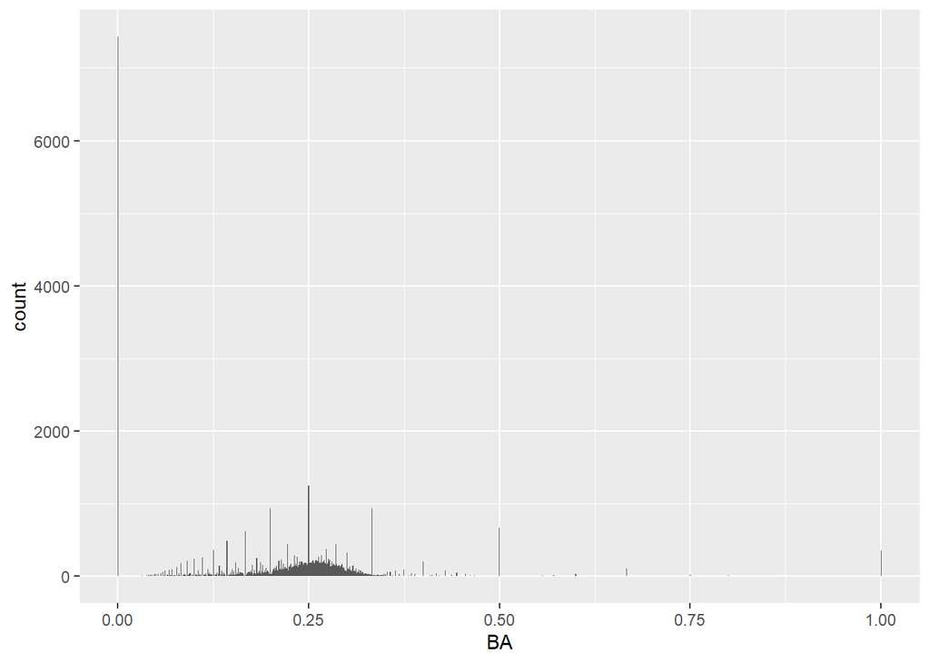

```r
df %>%
  ggplot() +
  geom_histogram(mapping = aes(x = BA), binwidth = 0.001)
```

We do see a peak around 0.25, but we see an incredibly high number of 0. This is most likely because the Lahman database includes data from all players, including those who may have been called up from the Minor Leagues for a short stint. Some of these players may only had less than five chances to bat (less than 5 `AB`). We can increase the minimum `AB` threshold to 100 to eliminate the 0 values.

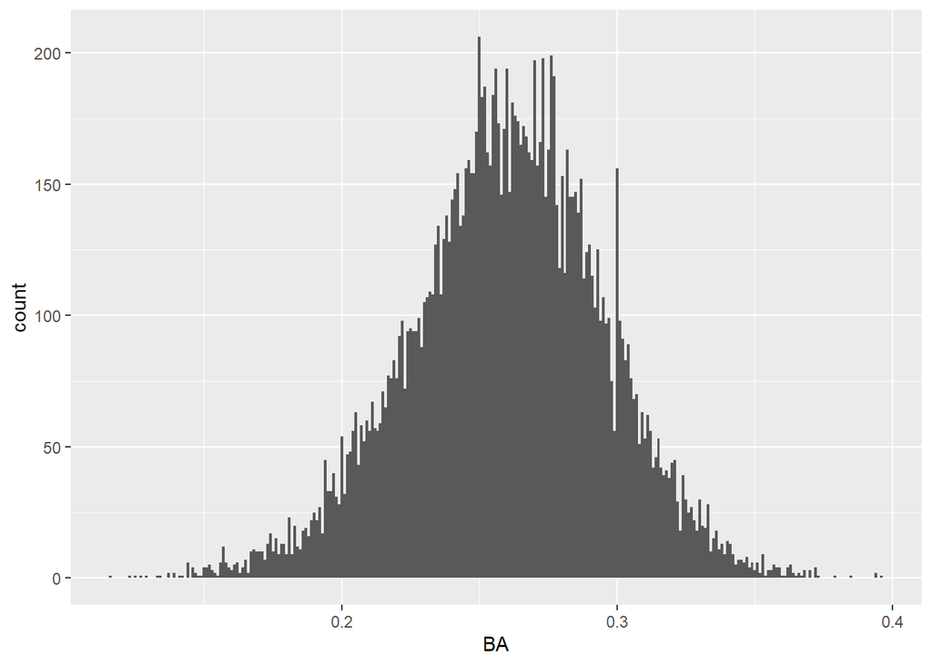

```r
df %>%
  filter(AB > 100) %>%
  ggplot() +
  geom_histogram(mapping = aes(x = BA), binwidth = 0.001)
```

This looks a lot like what we were looking for. We can increase the threshold even further to look at players who had more than 400 `AB`.

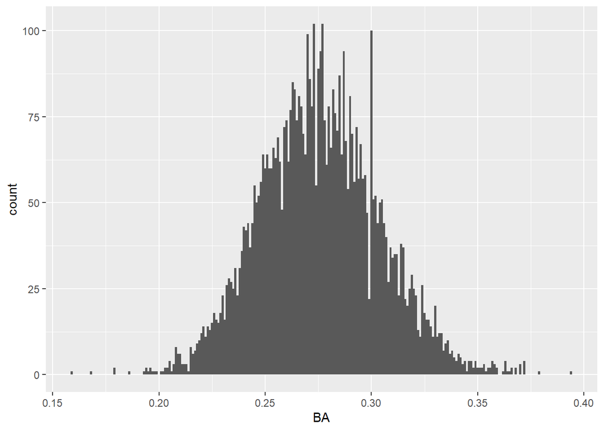

```r
df %>%
  filter(AB > 400) %>%
  ggplot() +
  geom_histogram(mapping = aes(x = BA), binwidth = 0.001)
```

The distribution seems very similar, although if you look closely there is a slight shift of the distribution to the right. It makes sense that players that have had a higher number of chances to bat have a higher batting average. Players that are more skilled are more likely to be given chances to bat. We can confirm this by calculating the mean for both scenarios.

```r
df %>%
  filter(AB > 100) %>%
  summarise(meanBA = mean(BA, na.rm = T))
```

```
## # A tibble: 1 x 1
##   meanBA
##    <dbl>
## 1  0.260
```

```r
df %>%
  filter(AB > 400) %>%
  summarise(meanBA = mean(BA, na.rm = T))
```

```
## # A tibble: 1 x 1
##   meanBA
##    <dbl>
## 1  0.276
```

Players that had at least 400 `AB` has a mean `BA` of 0.276, while players that had at least 100 `AB` has a mean `BA` of 0.260.  
Going back to the distribution graph of minimum 400 `AB`…

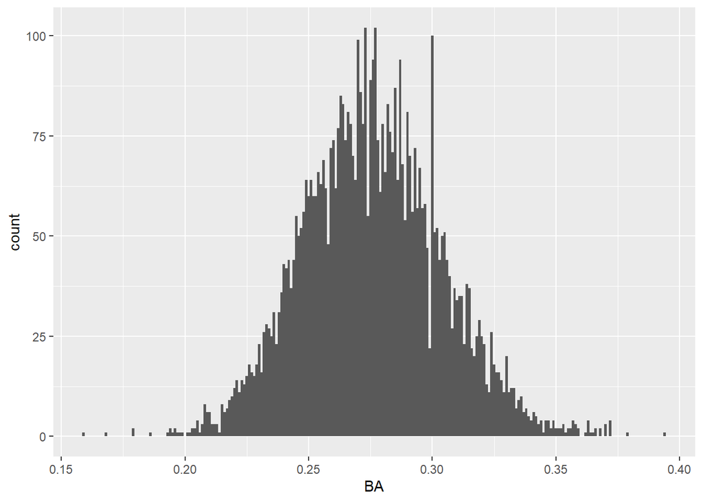

```r
df %>%
  filter(AB > 400) %>%
  ggplot() +
  geom_histogram(mapping = aes(x = BA), binwidth = 0.001)
```

There seems to be a random spike at ~0.300. Taking a closer look…

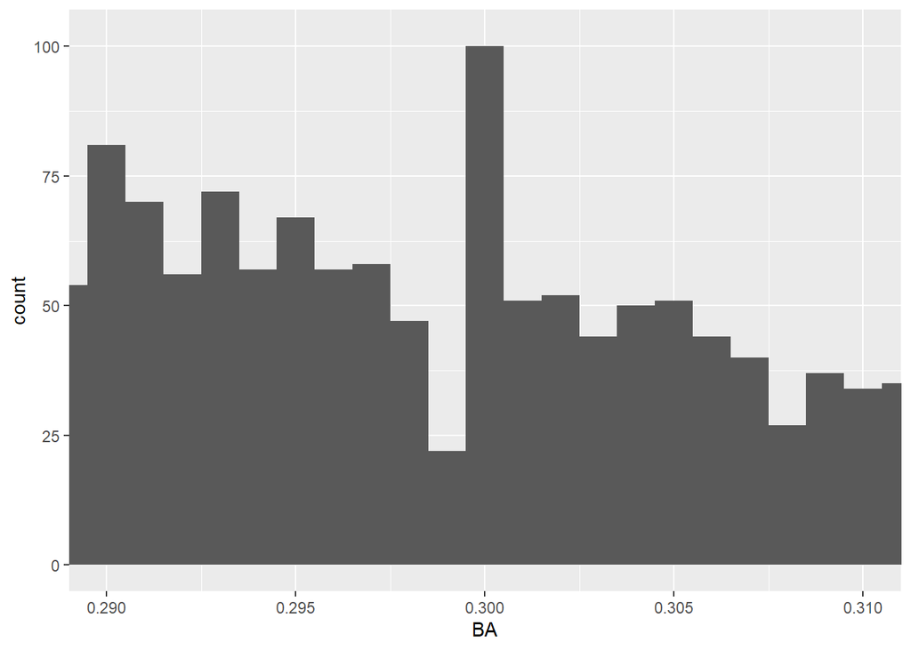

```r
df %>%
  filter(AB > 400) %>%
  ggplot() +
  geom_histogram(mapping = aes(x = BA), binwidth = 0.001) +
  coord_cartesian(xlim = c(0.29, 0.31))
```

There seems to be a spike at exactly 0.300. Examining the data…

```r
df %>%
  filter (AB > 400 & BA == 0.300) %>%
  select (BA, AB, H) %>%
  head()
```

```
## # A tibble: 6 x 3
##      BA    AB     H
##   <dbl> <dbl> <dbl>
## 1   0.3   530   159
## 2   0.3   540   162
## 3   0.3   470   141
## 4   0.3   540   162
## 5   0.3   550   165
## 6   0.3   460   138
```

There doesn’t seem to be anything particularly odd or unusual. I wanted to see if there are other spikes around other “common” numbers of batting average, such as “0.250” or “0.200” to see if there was a rough estimation during data entry.

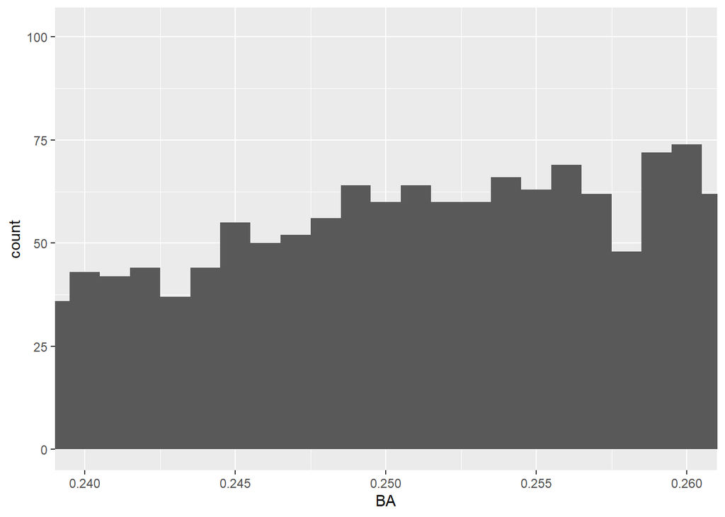

```r
df %>%
  filter(AB > 400) %>%
  ggplot() +
  geom_histogram(mapping = aes(x = BA), binwidth = 0.001) +
  coord_cartesian(xlim = c(0.24, 0.26))
```

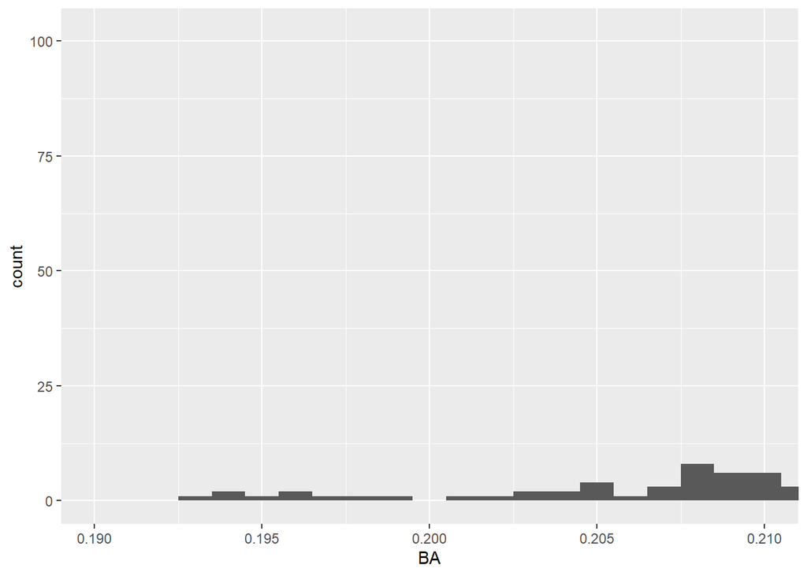

```r
df %>%
  filter(AB > 400) %>%
  ggplot() +
  geom_histogram(mapping = aes(x = BA), binwidth = 0.001) +
  coord_cartesian(xlim = c(0.19, 0.21))
```

No unusually high peaks exist at 0.250 or 0.200. I will conclude that the peak is purely by chance.

#### B. Home Run distribution

From my rough estimate coming from my knowledge of basic MLB stats, the average number of homeruns hit are probably around 10-15, but this number is limited to players who had a lot of `AB` exposures. Number of home runs hit in a season will have a higher variance than batting average, as it varies widely on a player by player basis.

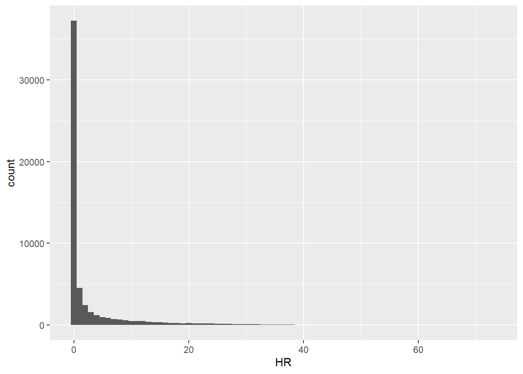

```r
df %>%
  ggplot() +
  geom_histogram(mapping = aes(x = HR), binwidth = 1)
```

Again, a high number of 0 home runs. We need to bring up the `AB` threshold again.

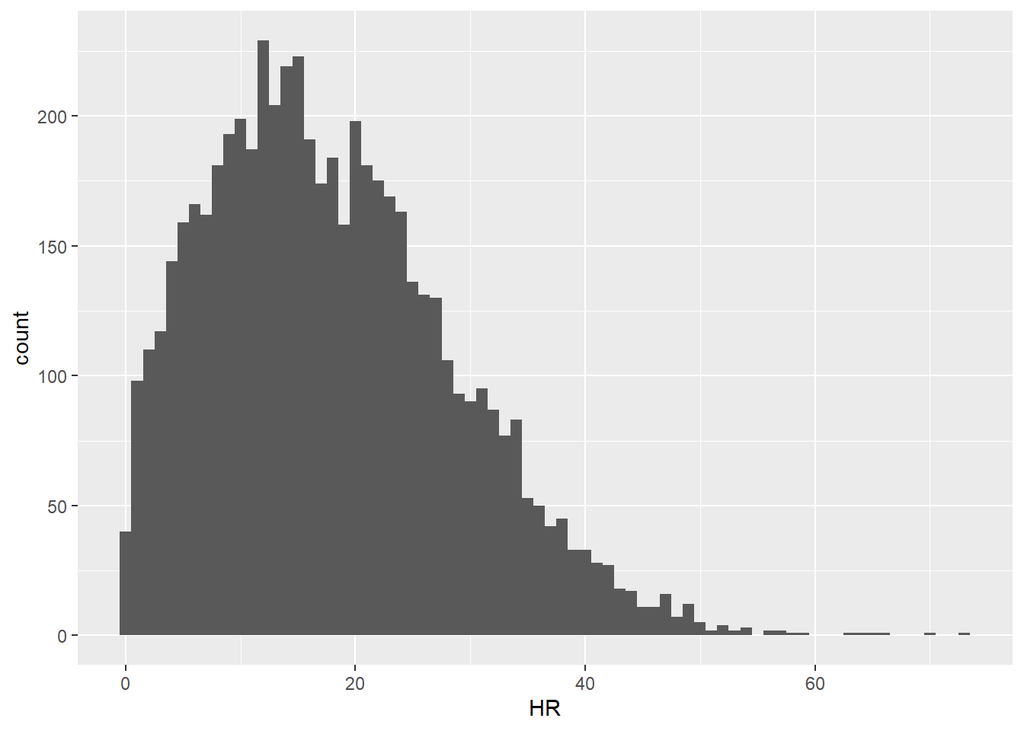

```r
df %>%
  filter(AB > 400) %>%
  ggplot() +
  geom_histogram(mapping = aes(x = HR), binwidth = 1)
```

We do see a peak around 15 `HR`. There seems to be a greater right skew compared to the batting average distribution graph, which looked more like a normally distributed graph. This can be explained by the fact that there are fewer players who have a lot of power that can hit many home runs.  
I wanted to see if there are any statistic that correlate with the number of home runs hit. Let’s filter for players that had at least 400 `AB` and above a 0.3 `BA`.

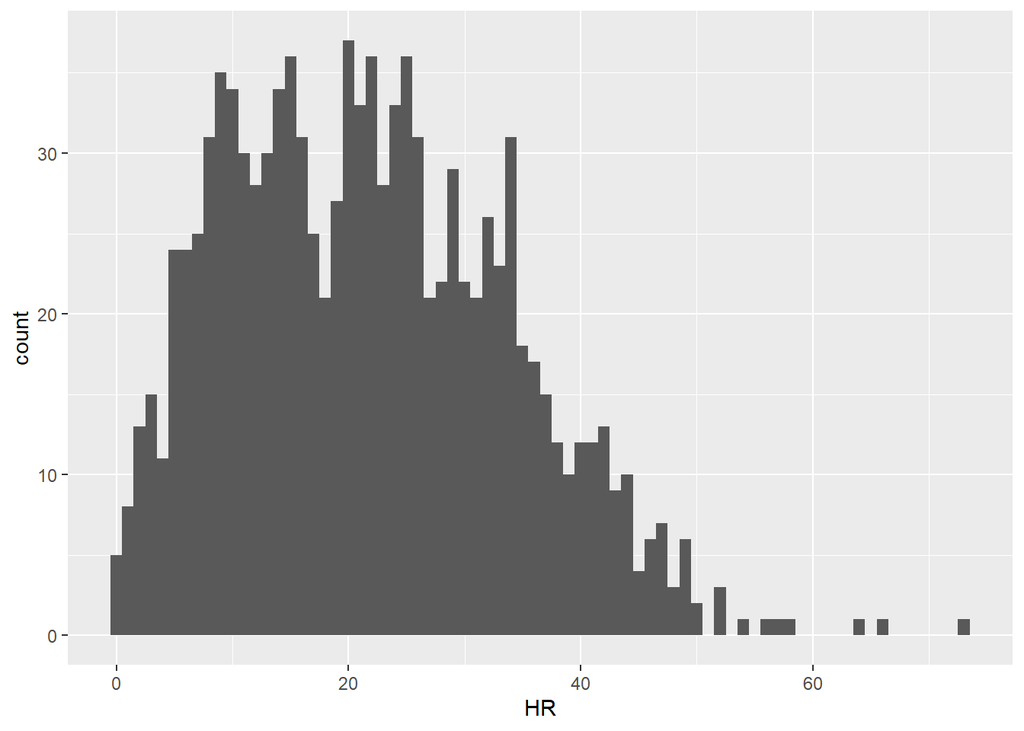

```r
df %>%
  filter (AB > 400 & BA > 0.3) %>%
  ggplot() +
  geom_histogram(mapping = aes(x = HR), binwidth = 1)
```

The graph seems slightly more normally distributed and the skew is less obvious, discounting the outliers of players who has hit more than 50 home runs. The distribution has shifted a bit right as well, hinting that a high batting average has some correlation with high numbers of homeruns hit.  
We can check out another statistic called `RBI`. `RBI` is short for Runs Batted In, or the number of runs a player caused to be scored. Home run hitters tend to have a high RBI. We’ll see if this is a better predictor of the number of home runs hit. I will filter for players who had more than 100 RBI, which usually indicates that a player had an extremely good season.

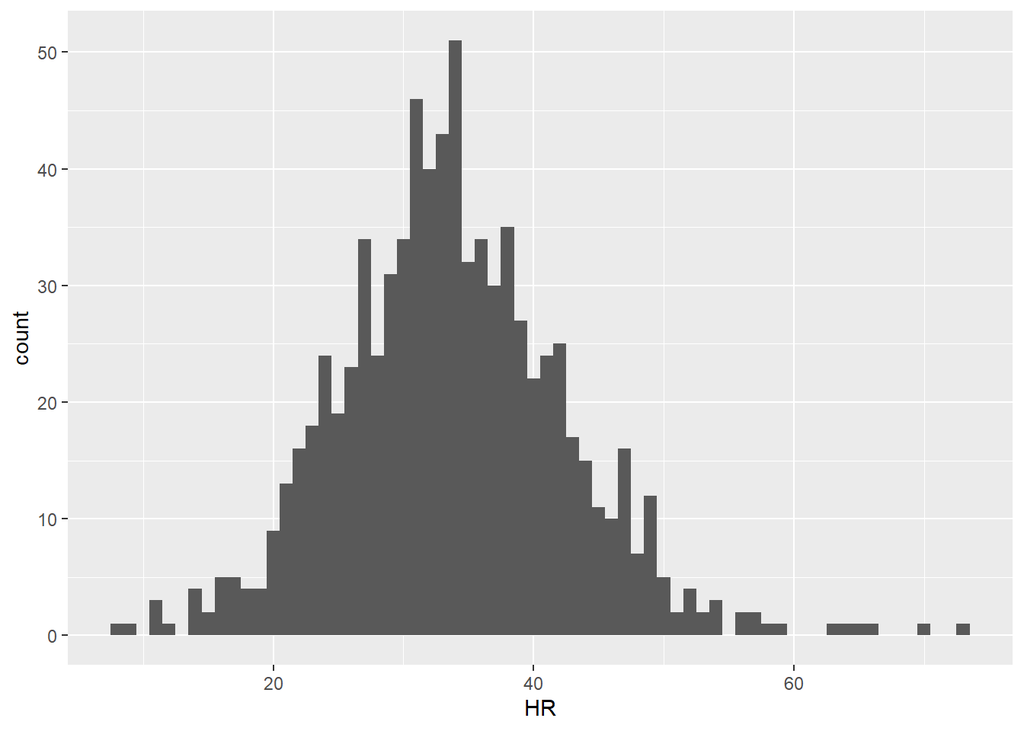

```r
df %>%
  filter (AB > 400 & RBI > 100) %>%
  ggplot() +
  geom_histogram(mapping = aes(x = HR), binwidth = 1)
```

The graph here has even less skew and has a more rightward shift compared to the other graphs, peaking at around 30 HRs. `RBI` seems to be a better predictor of number of `HR` hit. We can use a scatterplot to confirm this.

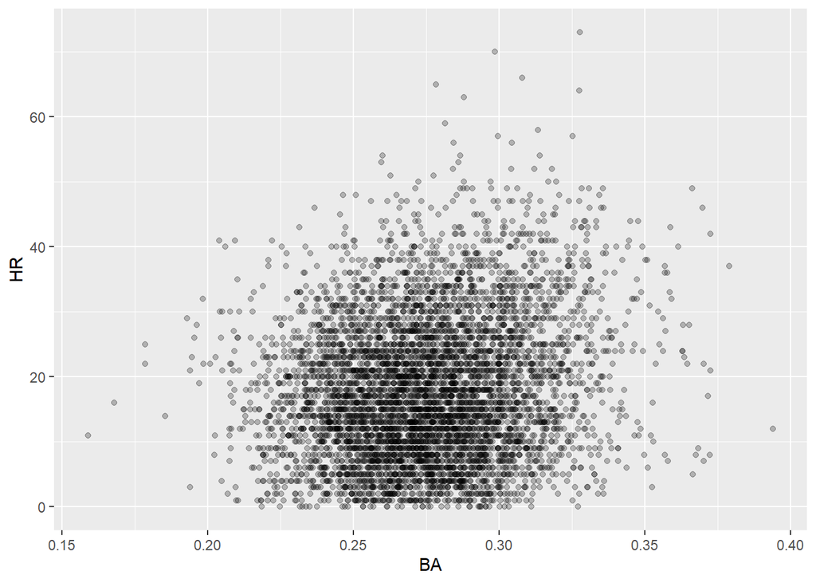

```r
df %>%
  filter (AB > 400) %>%
  ggplot() +
  geom_point(aes(x = BA, y = HR), alpha = 1/4)
```

It’s kind of hard to see a clear correlation between `BA` and `HR`. Using `RBI` instead…

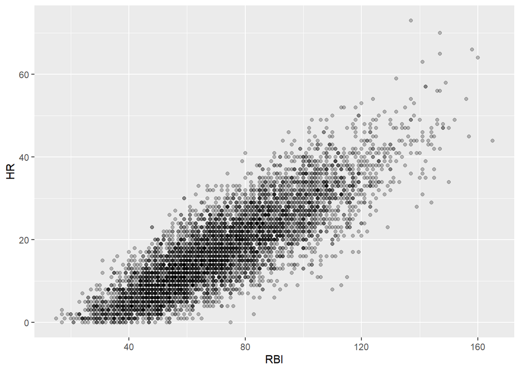

```r
df %>%
  filter (AB > 400) %>%
  ggplot() +
  geom_point(aes(x = RBI, y = HR), alpha = 1/4)
```

The correlation seems much more clear here. I wanted to try another variable, `BB`. `BB` or “Base on Balls”, more commonly known as “walks” is the number of times a player has drawn four balls. Good players often draw more walks because the pitchers are more careful about throwing a strike to them, since there is a good chance that they will hit the ball. High home run hitters tend to have high `BB` as well.

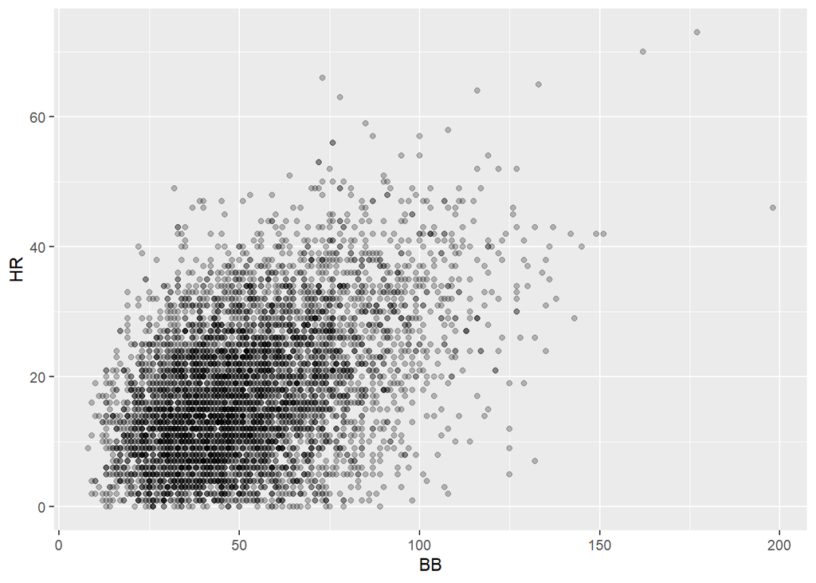

```r
df %>%
  filter (AB > 400) %>%
  ggplot() +
  geom_point(aes(x = BB, y = HR), alpha = 1/4)
```

The correlation seems a bit better than batting average, but it is not as clear as `RBI`.

Numerically calculating the correlation coefficient:

```r
df %>%
  filter (AB > 400) %>%
  select(HR, BA) %>%
  cor()
```

```
##           HR        BA
## HR 1.0000000 0.1647233
## BA 0.1647233 1.0000000
```

```r
df %>%
  filter (AB > 400) %>%
  select(HR, RBI) %>%
  cor()
```

```
##           HR      RBI
## HR  1.000000 0.847853
## RBI 0.847853 1.000000
```

```r
df %>%
  filter (AB > 400) %>%
  select(HR, BB) %>%
  cor()
```

```
##           HR        BB
## HR 1.0000000 0.4518436
## BB 0.4518436 1.0000000
```

HR and RBI has the greatest correlation (0.85), as predicted.